# A Global UNICEF Report on Child Nutrition

Author

Aswini Thakkellapati | A00045842 | DCU

Published

April 15, 2026

# Introduction

Every child deserves access to nutritious food and a healthy start in life. Yet millions of children around the world still struggle to get the nutrition they need.

This report explores:

- 🥗 Access to protein-rich foods for children
- 🌍 How nutrition varies across countries
- 📉 Whether things are improving over time

Using UNICEF data, we identify where children are most at risk and what factors influence these outcomes.

# Understanding the Data

- Total observations: **276 country-year records**
- Food consumption ranges from **11% to 94%**
- Most data comes from **lower-income countries**
- Median year: **2016 (recent data)**

# 1. Global Distribution of Child Nutrition (World Map)

This map shows how access to nutritious food varies across the world.

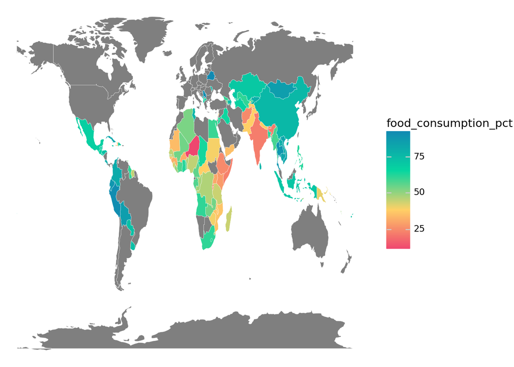

👉 Children in some regions—especially parts of Africa and South Asia—have significantly lower access to nutritious food.

# 2. GDP vs Nutrition (Scatter Plot)

This chart shows how a country’s wealth relates to child nutrition.

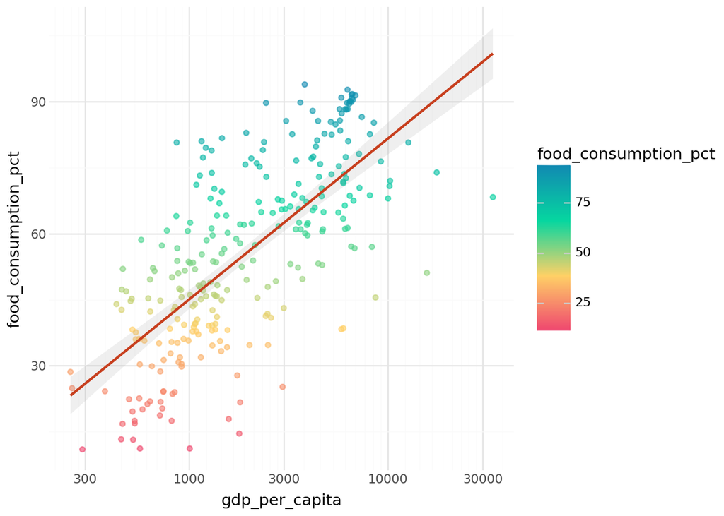

👉 Wealthier countries tend to have better nutrition—but not always.

# 3. Has Nutrition Improved Over Time? (Trend)

This chart shows how global nutrition has changed over the years.

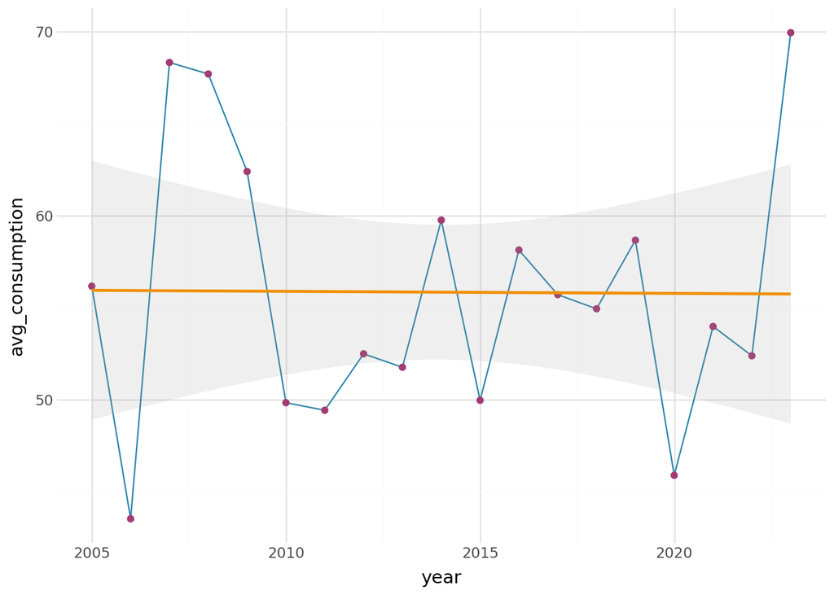

# 4. Nutrition by Income Group

This chart compares nutrition levels across income groups.

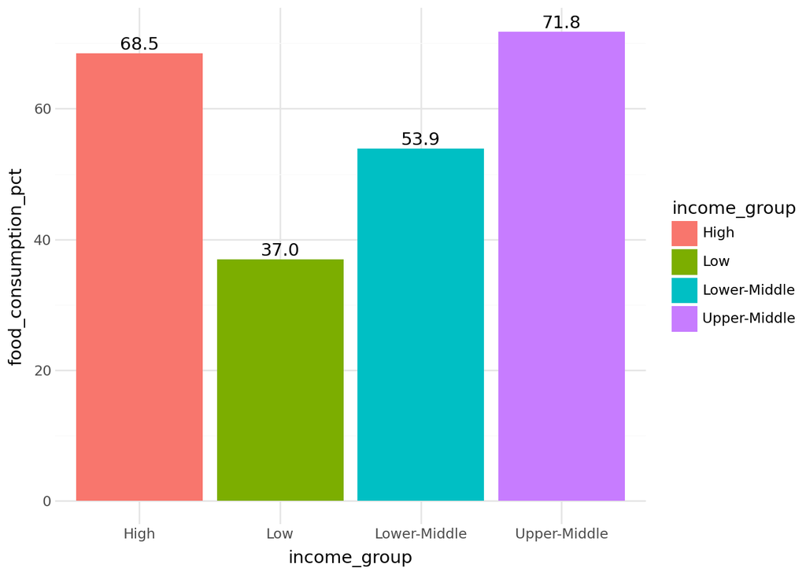

👉 Lower-income countries clearly face greater challenges.

# Conclusion

Every child deserves equal access to nutrition and a healthy future 🌍